# WeRateDogs - what dogs do we rate?

Christine Shuttleworth, 12th of October 2020

WeRateDogs rates super-cute dog images. Dog owner send images of their little rascals (mostly dogs but not always) to be rated. This twitter feed is very amusing harmless fun. With 8.8 Mio followers WeRateDogs is also extremely successful. Looking at all the tweets in this feed, I asked myself, who is the cutest of them all? There is no right answer to this of course but looking at some of the tweets between 2015 and 2017 there are some interesting trends to be seen.

## Who is the cutest of them all?

Many different dog breeds are rated on WeRateDogs. I wanted to know, which breed was rated the most and of the ones that were rated at least 20 times, which breed had the highest average rating. To find the answer, I used data that tries to predict the dog breed from the images that were attached to the tweets.

**Result:** From all the images with single dogs that were rated, the **Golden Retriever** was rated the most often. Not surprising - it's the familiy dog number 1! On average the highest rated was the **Samoyed** and very handsome they are indeed.

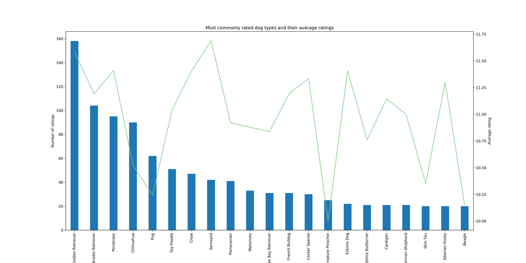

Here they are:

### Golden Retriever

[figure not shown]

### Samoyed

[figure not shown]

Not sure why Pugs don't get such high ratings. Look how cute:

### Pug

[figure not shown]

Then I asked myself - these are the dogs that are rated on average the highest by WeRateDogs, but which breeds of dogs are most liked by the followers of WeRateDogs? Looking at all the favorite votings for the different dog breeds, I found that the **Bedlington Terrier** has been faved the most - on average 30 000 times! Here is a Bedlington Terrier:

### Bedlington Terrier

[figure not shown]

Ups! Maybe the dog breed prediction was not as good as I thought ... Very cute however! This is were I stopped looking at dog breeds as I think the algorithm is just not good enough predict dogs reliably!

So let's look at individual tweets. What individual dog picture got the highest favorite count? And here it is: A very supportive puppy at woman's march! Well done!!

[figure not shown]

The image that was retweeted the most is actually a video. Look at this clever dog blowing bubbles (you will need to log into Twitter):

Dog blowing bubbles: https://twitter.com/dog_rates/status/739238157791694849/video/1

The data that I looked at span 2 years. To see how consistent the ranking was I looked at a timeline of average monthly rankings. Did WeRateDogs rank the dogs fairly over time?

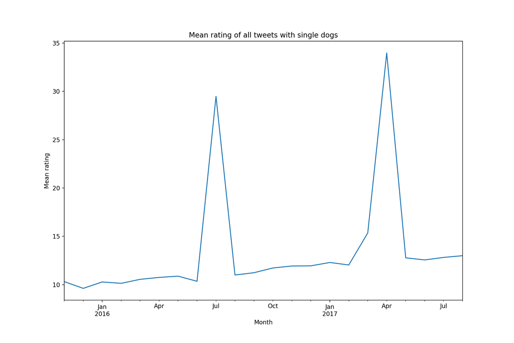

I hope you enjoyed this lighthearted summary of WeRateDogs and are ready to see some more cuties here: https://twitter.com/dog_rates